# Nemo Gradebook: An R Package for Calculating Course Grades

4 November 2024

# Summary

`Gradebook` allows for accurate and systematic computations of the final course letter grades. These computations require two inputs: a specifically structured YAML grading policy file representing the class syllabus and the assignment grades in CSV (comma-separated value) format from Gradescope (Singh et al. 2017) (or other similar learning management systems). The package uses these two inputs to break down wide range of complex syllabi into the series of nested methodical aggregation steps.

# Statement of Need

While the final grade at the end of a course is an elementary part of most college courses, the computations for these grades quickly become deceptively intricate, especially with larger STEM classes that use various complexities to accommodate a diverse student body. Even though most classes use slight variations of the same policies, many LMS cannot sustain these complex computations. In response, courses will turn to hard-coded scripts. These scripts quickly accumulate hundreds of lines of code, and there is no method to assess accuracy of the final computation.

Grading Workflow WITH Nemo Gradebook

Grading Workflow WITHOUT Nemo Gradebook

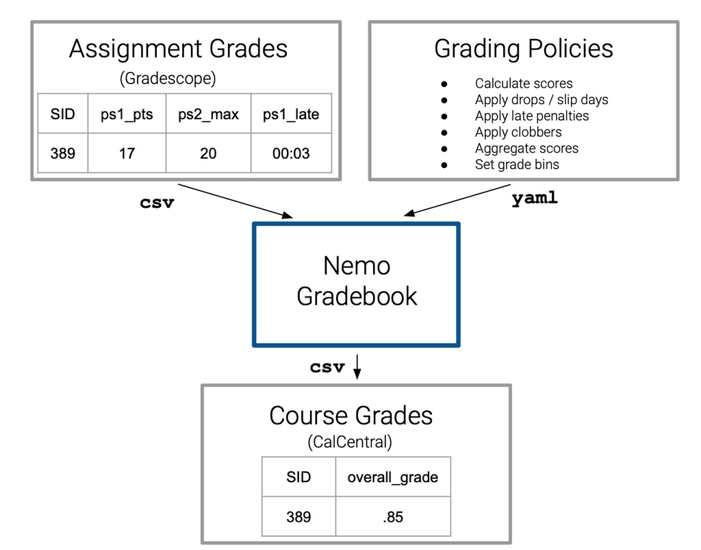

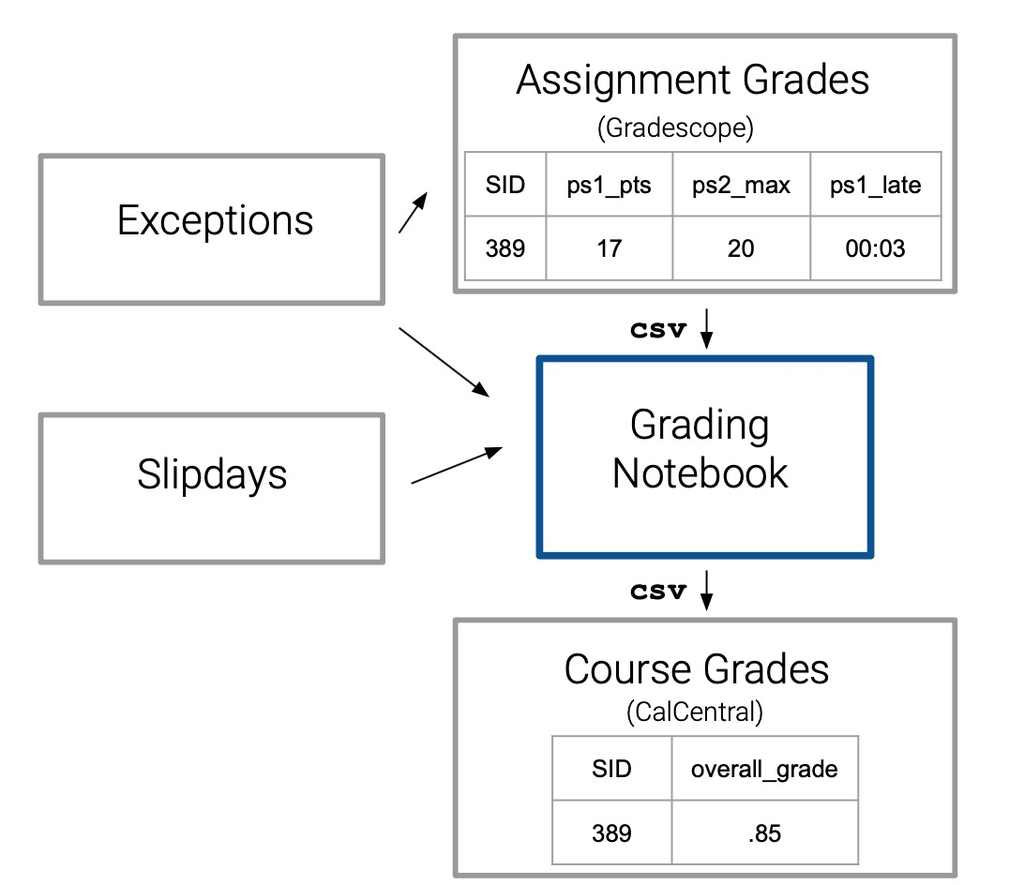

# Underlying Principle

The details of the course grading structure – usually detailed in the syllabus or on the class website – can be articulated in YAML format using a series of accepted keys (e.g. `score`, `aggregation`, `lateness`, `drop_n_lowest`, etc.) and their corresponding inputs; more direction about creating a policy file is provided in the `Building a Policy File` vignette. The nested structure of this policy file reflects the nested structure of the course grade. The assignment scores come directly from Gradescope in a .csv file. These two files (the YAML policy file and the Gradescope data) function as the two inputs for `gradebook`’s primary and overarching function: `get_grades()`. After pulling the assignment data from Gradescope and converting their syllabus into a YAML policy file, this singular function computes the entirety of the final course grad computation.

While `get_grades()` encapsulates the entire functionality of the R package, it is compromised for four sequential functions:

- `process_gs()` ensures the correct format of the Gradescope csv.
- `process_policy()` similarly ensures the correct format of the policy file.
- `reconcile_policy_with_gs()` checks the compatibility of the policy file and the Gradescope data.
- `calculate_grades()` computes the course grades and returns the final grade (and the scores for every intermediate category) appended to the original Gradescope data.

# Comparison to Other Packages

Most other commonly-used packages – particularly for R packages – are used for grading on an assignment-level basis. For example, the `gradeR` package “helps grade your students’s assignment submissions that are R Scripts” whereas `gradebook` is used for the computations of the final, overall course grade (Brown 2021). The software that has the most similar computational purpose as `gradebook` are popular learning-management systems (LMS) used in higher education. This includes Canvas (Canvas Community 2024), Moodle (Moodle Docs 2024), Blackboard Learn (Blackboard Help 2024), and D2L Brightspace (D2L Brightspace Community 2024), all of which provide an integrated gradebook that allow the instructor to specify the manner in which assessment scores are used to calculate a final course grade.

# Acknowledgements

The authors would like to thank lain Carmichael, Calvin Carter, and Zach Turner for helpful ideas and discussions throughout the development of this project.

As of summer 2024, we are funded by the RTL grant from the Statistics Departmemt at University of California, Berkeley.

As of October 2024, there is a pending poster submission to Technical Symposium on Computer Science Education (SIGCSE) that utilizes this package, called “Your Grades Are Wrong - Nemo Gradebook: A tool for easy, accurate course grades”. The poster was submitted by the same set of authors.

# References

Blackboard Help. 2024. “Calculate Grades.” https://help.blackboard.com/Learn/Instructor/Ultra/Grade/Grading_Tasks/Calculate_Grades.

Brown, Tylor. 2021. “gradeR: Helps Grade Assignment Submissions That Are r Scripts.” *GitHub Repository*. https://github.com/tbrown122387/gradeR.git; GitHub.

Canvas Community. 2024. “How Do i Use the Gradebook?” https://community.canvaslms.com/t5/Instructor-Guide/How-do-I-use-the-Gradebook/ta-p/701.

D2L Brightspace Community. 2024. “About Grades.” https://community.d2l.com/brightspace/kb/articles/3305-about-grades.

Moodle Docs. 2024. “Grade Calculations.” https://docs.moodle.org/404/en/Grade_calculations.

Singh, Arjun, Sergey Karayev, Kevin Gutowski, and Pieter Abbeel. 2017. “Gradescope: A Fast, Flexible, and Fair System for Scalable Assessment of Handwritten Work.” In *Proceedings of the Fourth (2017) ACM Conference on Learning @ Scale*, 81–88. L@s ’17. New York, NY, USA: Association for Computing Machinery. https://doi.org/10.1145/3051457.3051466.

Voutov*, Monika, Nikita Jayaprakash*, and Andrew Bray. 2024. “Nemo Gradebook Web App.” *GitHub Repository*. https://github.com/gradebook-dev/gradebook-app.git; GitHub.